# The Effect of Downvotes on Content Creation: Evidence from Social Media

Converted from PDF `Deolankar-DownvotesContentCreation-2026-JMR.pdf` · 21 pages · anchors: page `#pN`, block `#pN-bK`

Page 1

## The Effect of Downvotes on Content Creation: Evidence from Social Media

#### Varad Deolankar, Jessica Fong , and S. Sriram

Abstract This article studies how receiving negative peer feedback, in the form of downvotes, affects user-generated content creation on Reddit. The authors focus on the following outcomes: (1) propensity to post (incidence), (2) where users post, and (3) the strength of opinion (intensity), measured by the extremity of users’ texts. The latter two outcomes are important given ongoing concerns about how social media platforms may contribute to echo chamber formation and polarization. The authors find that negative feedback, relative to no feedback, increases users’ subsequent posting activity, and they do not find evidence that receiving negative feedback drives users away, alleviating concerns about echo chamber formation. In addition, negative peer feedback moderates extreme sentiments—when initial views are extreme, users temper the intensity of their subsequent posts. These effects of negative feedback are consistent with users attempting to maintain their reputation.

Keywords social media, user-generated content, polarization, customer retention, platform design

Online supplement: https://doi.org/10.1177/00222437261417657

Submitted October 2, 2024

Social media platforms enable users to connect, share information, and exchange opinions, and they often promote this process by incorporating peer feedback. For example, Facebook users can “like” posts, and Reddit users can give peers “badges.” Existing research has shown that positive peer feedback, such as upvotes (Jin et al. 2015), badges (Burtch et al. 2022; Gallus 2017; Huang, Kaul, and Narayanan 2022), comments (Wang and Majeed 2023), and the number of followers (Toubia and Stephen 2013), can increase content generation and promote user engagement.

While many social media platforms allow users to provide positive feedback through likes and upvotes (e.g., Instagram), some also solicit negative feedback. For example, Reddit users can downvote posts. In addition, platforms like YouTube, Twitter (now X), and TikTok have recently experimented with allowing negative feedback in the form of dislikes and downvotes (Cohen 2022; Ingram 2022; The YouTube Team 2021). Although negative feedback can be useful for regulating content and improving recommendation algorithms, it can also impact the production of user-generated content (UGC). On the one hand, negative feedback has the potential to diminish intrinsic motivation (Deci and Cascio 1972), thereby potentially reducing UGC output. On the other hand, negative feedback can generate attention (Berger, Sorensen, and Rasmussen 2010) and thus motivate users to increase

UGC production. In addition to impacting the volume of UGC, negative feedback may also shape the tone of the content itself. For instance, if negative feedback is undesirable (e.g., Dholakia, Bagozzi, and Pearo [2004] find that negative feedback hampers the social enhancement value that individuals derive from gaining acceptance and approval of others), then users may adapt their future content to align more closely with popular opinion or tone down the intensity of their comments.

Alternatively, negative feedback can cause users to become defensive (Nussbaum and Dweck 2008) or induce users to strengthen their (unpopular) opinions because it can generate more attention (Cheng, Danescu-Niculescu-Mizil, and Leskovec 2014). Thus, the consequences of negative feedback not only have managerial implications for the supply of UGC but also have potential policy implications for echo chamber formation and polarization on social media platforms.

In this article, we study the role of negative peer feedback in driving the creation of UGC and ask the following questions.

Varad Deolankar is Assistant Professor, National University of Singapore, Singapore (email: varad.deolankar@nus.edu.sg). Jessica Fong (corresponding author) is Assistant Professor, University of Michigan, USA (email: jyfong@ umich.edu). S. Sriram is The Dwight F. Benton Professor of Marketing, University of Michigan, USA (email: ssrira@umich.edu).

Article

Journal of Marketing Research

2026, Vol. 63(4) 767-787 © American Marketing Association 2026

Article reuse guidelines: sagepub.com/journals-permissions DOI: 10.1177/00222437261417657

journals.sagepub.com/home/mrj

Page 2

First, how does receiving negative feedback affect users’ propensity to create subsequent content, relative to receiving no feedback? For the remainder of this article, we refer to “incidence” as the user’s propensity to create content, which includes whether they create content as well as how much content they create in a given period. Second, how does negative feedback affect where they post? In particular, does negative feedback drive users away from subgroups where their opinions may not be popular? Third, does negative feedback moderate or magnify the intensity of the opinions expressed in subsequent content? Answers to these questions will enable us to comment on the role of negative feedback in influencing the volume and nature of UGC supplied to such platforms. In addition, the findings on where users post and the intensity of their posts could also provide insights into the role of negative peer feedback in echo chamber formation and polarization. These issues have garnered interest amid growing concerns that social media platforms contribute to ideological segregation and extreme discourse (Cinelli et al. 2021; Ross Arguedas et al. 2022).

We explore these questions in the context of Reddit, where users’ posts accumulate peer feedback through upvotes and downvotes. Although feedback can be received in other ways (e.g., text replies), upvotes and downvotes provide a straightforward metric to quantify the valence of feedback. Furthermore, discussions on Reddit are often opinion-based, allowing users flexibility to adjust their content in response to peer feedback. This subjectivity enables us to infer how feedback shapes the nature of content produced. We collected data on posting behavior, post scores, and karma (a user’s reputation score) for a sample of Reddit users on a daily basis, allowing us to track the content creation of each user as well as the feedback they receive (i.e., the change in post-level scores and user-level karma) over time. Since comments represent the majority of UGC on Reddit, we focus on commenting behavior in our analysis.<sup>1</sup>

Measuring the causal effect of feedback on posting behavior is challenging for several reasons. First, users may differ in their intrinsic propensity to create content and in their likelihood of engaging with controversial or provocative topics (e.g., “troll” behavior), which may also increase their exposure to negative feedback. Second, UGC activity can vary over time (e.g., day of the week). We can control for these two confounds using a rich set of fixed effects. Third, unobserved factors, such as political events or the release of a new movie, may impact both the amount and intensity of feedback generated on certain topics. Such unobserved factors that vary across topics and over time can pose a serious challenge to inferring a causal relationship between feedback and subsequent UGC.

To overcome the latter challenge, we use an identification strategy that assumes that feedback is likely to be more salient to users when their score or karma crosses certain

thresholds, such as if the left digit changes (Anderson and Simester 2003; Bizer and Schindler 2005; Husain, King, and Mohan 2021; Lacetera, Pope, and Sydnor 2012; List et al. 2023; Strulov-Shlain 2022; Thomas and Morwitz 2005), or the sign changes. For example, because of left-digit bias, negative feedback is more likely to be salient if the user’s karma decreases from 101 to 99, as opposed to a decrease from 102 to 100, despite both receiving the same amount of negative feedback (−2). Similarly, negative feedback is more salient if a post’s score decreases from 2 to −1 as opposed to a decrease from 4 to 1. Thus, we assume that, conditional on the amount of feedback, karma, and score, changes in the left digit of karma or the sign of a comment’s score—both of which shift the salience of negative feedback—are exogenous to the user’s posting behavior.

We find that, on average, more salient negative feedback increases content creation. Although this might imply at first glance that negative feedback does not contribute to echo chamber formation, this average effect may mask heterogeneity. Users could respond to negative feedback by disengaging from the specific space where it was received and redirecting their activity toward other spaces. Such behavior would be indicative of echo chamber formation. However, we find no empirical evidence that negative feedback discourages content creation within the original space. Therefore, our results do not support the idea that negative feedback contributes to echo chamber formation.

To study whether negative feedback drives users to moderate extreme views or amplify them, we measure the intensity of the text using Google’s Natural Language application programming interface (API). We focus on intensity because more intense language is often associated with greater polarization (Asker and Dinas 2019). We find that negative feedback induces users to moderate the intensity of their tone in subsequent posts, especially when the user’s original comment had a high intensity score. This effect applies to both controversial and noncontroversial topics. Although there may be several mechanisms at play, our results are consistent with reputation management, wherein the change in content creation after receiving negative feedback is driven by the user’s desire to salvage their standing on the platform.

Our findings have several implications for platform design and policy. For platform managers, the results suggest that allowing negative feedback does not suppress overall user engagement but may instead encourage users to not only post more content but also expand activity into more spaces. This can be beneficial for sustaining platform-wide UGC. Our results also suggest that negative feedback does not deter users from creating content in spaces where they received negative feedback. Thus, allowing users to provide negative feedback might not exacerbate echo chamber formation. Furthermore, given that negative feedback reduces the intensity of subsequent posts, peer feedback systems could potentially play a role in influencing polarization on social media.

The remainder of the article is structured as follows. First, we present the related literature and our contributions in more

1 The other form of UGC is submissions, which is the parent post on which other users can comment. Comments account for 97.6% of UGC in our data.

768 Journal of Marketing Research 63(4)

Page 3

detail. Second, we provide background on our empirical setting and present summary statistics. We then present our empirical analyses for incidence and intensity, respectively. Next, we explore potential mechanisms for our results and discuss our findings’ implications for platforms, echo chambers, and polarization. We conclude with limitations and directions for future research.

#### Related Literature

Our article relates to the literature in marketing and information systems that studies UGC creation on social media platforms. Extant literature has identified several reasons why users create content, such as social network ties (Peng et al. 2018; Shriver, Nair, and Hofstetter 2013), intrinsic and image-related utility (Moe and Schweidel 2012; Toubia and Stephen 2013; Zhang and Zhu 2006), etc. Our article most closely relates to the stream of research that focuses on how feedback impacts UGC.

The literature has primarily focused on positive feedback, which is often received in the form of platform and peer recognition. This has been studied in various contexts, such as Wikipedia (Gallus 2017), online education (Denny 2013), an image-sharing social network (Huang, Kaul, and Narayanan 2022), and Reddit (Burtch et al. 2022; Lu, Xie, and Chen 2022). These studies have consistently documented a positive causal relationship between recognition and UGC production.

Another stream of literature has examined the impact of peer feedback more broadly. Eckles, Kizilcec, and Bakshy (2016) find that on Facebook, a 10% increase in feedback, as defined by comments and likes, increases the number of comments the individual subsequently created by 9.6%. Mummalaneni, Yoganarasimhan, and Pathak (2022) investigate the heterogeneous effects of peer engagement on Twitter. They find that an increase in one unit of feedback (likes, comments, or retweets) increases the number of tweets composed by .042, or .1% on average. Their findings also reveal that while feedback does not significantly influence most Twitter users, it does impact a small subset of highly responsive users. These responsive users increase time spent on Twitter, generate more new posts, and send a greater number of “favorites” to other users. However, the main form of feedback in these studies is positive (e.g., likes and retweets), and they do not focus negative feedback.

The literature on negative peer feedback’s impact on UGC is limited. Prima facie, negative peer feedback might seem to simply be the opposite of positive feedback—if positive peer feedback increases UGC production, negative feedback should decrease it. Using data on reviews for restaurants and reviews on Amazon, Zhu, Khern-am nuai, and Yu (2025) and Shen, Liu, and Wang (2025), respectively, find that negative peer feedback increases users’ likelihood of creating future content. For example, Shen, Liu, and Wang document that not providing negative social feedback can diminish reviewers’ review propensity by 7.85% and review effort by 14.82% in the short term. Additionally, negative feedback is associated with

higher-quality content, including longer reviews with more pictures (Zhu, Khern-am nuai, and Yu 2025) and better readability (Shen, Liu, and Wang 2025). For news websites, Cheng, Danescu-Niculescu-Mizil, and Leskovec (2014) find that users are 30% more likely to comment again after receiving downvotes. However, unlike Zhu, Khern-am nuai, and Yu and Shen, Liu, and Wang, they find subsequent posts of lower quality as measured by human-labeled text quality scores.

Our study contributes to this literature not only by examining how negative feedback influences posting frequency but also by investigating what users say and where they choose to say it. As previously mentioned, these outcomes have implications for echo chamber formation and polarization—issues that have sparked increasing concern in social media in particular. Aggregate effects of negative peer feedback on content quantity and quality cannot speak to these implications. Rather, we need to assess (1) whether negative feedback suppresses content creation where such feedback originated (a sign of echo chamber formation), while increasing content creation elsewhere, and (2) the extremity of the content, which quality does not capture. Additionally, in the contexts studied by Zhu, Khern-am nuai, and Yu (2025) and Shen, Liu, and Wang (2025), echo chamber formation is less applicable than in social media settings, since individuals typically do not continue engaging in the same space where they received negative feedback (e.g., by leaving multiple reviews on the same product).

Our article also contributes to the literature on customer engagement. Connecting to the conceptual model of customer engagement in Van Doorn et al. (2010), we provide an empirical study on how negatively valenced customer engagement can impact the firm (i.e., the social media platform) in terms of its product (i.e., the quantity and nature of the UGC). We provide a case study in showing that negatively valenced customer engagement may not always hurt the firm.

Our article also has implications for echo chamber formation and polarization. Previous research has identified several human tendencies that contribute to polarization and echo chambers on social media: homophily, which refers to the inclination to interact primarily with similar individuals (Kandel 1978; McPherson, Smith-Lovin, and Cook 2001); confirmation bias, which involves seeking and favoring information that aligns with preexisting beliefs (Freedman and Sears 1965; Frey 1986; Stroud 2008); and the tendency to share more polarizing content (Yoganarasimhan and Iakovetskaia 2024). These tendencies, amplified by algorithmic recommendations, can lead to polarization and echo chambers on social media (Pariser 2011; Sunstein 2009). Recent studies have explored the role of recommendation systems in social media polarization. For example, Dandekar, Goel, and Lee (2013) show that an algorithm that recommends the item that is most relevant to a user, as determined by a PageRank-like score (Page et al. 1999), is always polarizing. Levy (2021) studies the consumption of news on social media and documents that social media algorithms limit exposure to counterattitudinal news and thus increase polarization. However, Guess et al. (2023) did not

Deolankar et al. 769

Page 4

find evidence of increased polarization when social media feeds were sorted chronologically versus algorithmically. Huang, Choi, and Wan (2024) identify another source of polarization on Reddit: biased removal of content by politically biased human moderators. We contribute to this literature by showing that enabling negative peer feedback mechanisms may help encourage more moderate discourse without exacerbating ideological segregation.

To summarize, we study how negative feedback received by a user impacts that user’s UGC in three ways: (1) their propensity to post, (2) where they post, and (3) the intensity of their posts. Of these, (1) and (2) have direct implications for echo chamber formation. However, since we only consider how the focal user modifies the intensity of their posts as a result of receiving negative feedback, (3) cannot directly tell us about polarization. Nevertheless, since polarization is usually associated with the extremity of views expressed by users (Asker and Dinas 2019), the findings from our research have implications for polarization of content on social media.

#### Setting and Data

The empirical context of our article is Reddit, a social media platform with a forum-style discussion structure. Users contribute to Reddit by posting content in communities called “subreddits.” Content can be either a “submission,” wherein a user starts a new topic for discussion, or a comment that users can make under a submission. In Web Appendix A, Figure WA.1 displays an example of a submission and Figure WA.2 displays examples of comments under a submission. In the remainder of our article, we refer to both submissions and comments as “posts.”

Reddit is an ideal setting for our study for the following reasons. First, often referred to as “the front page of the internet,” Reddit is one of the most popular websites in the world, with over 50 million active users per day and over 13 billion posts.<sup>2</sup> The topics discussed on Reddit are often opinion-based (e.g., “What is your favorite restaurant in Portland?”). This provides a setting where users have the latitude to take multiple perspectives without being objectively incorrect. Second, Reddit allows users to provide negative peer feedback on UGC in the form of downvotes, a feature crucial to our study. Users can upvote or downvote content, and the platform summarizes these at two different levels of aggregation. At the post level, Reddit reports the “score,” which is the net difference between the number of upvotes and downvotes. An important detail to note is that users only observe the score and not the absolute number of upvotes and downvotes. At the user level, the platform provides an overall measure of reputation in the form of submission and comment “karma” points, which, in turn, are functions of the total feedback received by the user over their lifetime. A user’s submission (comment) karma

increases with the upvotes they receive on their submissions (comments) and decreases with the downvotes on their submissions (comments).<sup>3</sup> The score of each post is publicly displayed next to or under the post, as shown in Figures WA.1 and WA.2.

Users can also receive negative feedback in the form of comments (i.e., text replies) from their peers.<sup>4</sup> We focus on downvotes instead of replies for several reasons. First, our focus on downvotes was motivated by the recent decisions by social media platforms such as YouTube, X, and TikTok regarding allowing users to provide downvotes and dislikes. Second, on Reddit, downvotes (and upvotes) are far more prevalent than replies.<sup>5</sup> Nontext feedback, such as likes, is more common than comments in other settings as well (e.g., Facebook; Lee, Hosanagar, and Nair 2018).

#### Data Collection

We observe the following time-invariant attributes for each user: their account creation date, submission karma, and comment karma before the data collection period. During the collection period, we observe their submission and comment karma at the daily level. We also observe every user’s posts created. For each post, we observe the author, the post type (submission or comment), the content, and the subreddit where the content was posted. Importantly, we also observe each post’s score each day for two weeks from the date it is posted. This enables us to track how the score for each post changes over time. We define feedback as the change in a post’s score or a user’s karma over time, since only the net

2 See https://www.redditinc.com/ and https://www.statista.com/statistics/ 443332/reddit-monthly-visitors (both accessed December 2022).

3 A user’s comment karma is bounded below by −100. Reddit has not revealed the exact formula for determining karma from upvotes and downvotes. More information on how karma is calculated can be found at https://reddit. zendesk.com/hc/en-us/articles/204511829-What-is-karma (accessed May 2023). 4 Users can also receive private messages, which we do not observe. 5 In a small sample analysis where we observe the evolution of all replies to a comment, we find that the average comment has an absolute score change of .4254 and receives .000977 replies. 6 This sample is smaller than 50 × 500 = 25,000 because not all subreddits had at least 500 unique submission creators and not all users posted during the observation period.

770 Journal of Marketing Research 63(4)

Page 5

score—not the separate counts of upvotes and downvotes—is visible to users. This implies that if we observe a score of, say, 10 on a given day t, neither we nor the user can tell whether the post received 10 upvotes and 0 downvotes or 11 upvotes and 1 downvote. However, if we observe that a post’s score decreases by one from day t −1 to t, we know that the post received one more downvote than upvote during that period. The same is true for a user’s karma, which is a function of upvotes and downvotes. Thus, we define feedback as the change in the post’s score or the user’s karma. That is, a decrease in the score or karma indicates that the user received negative feedback, while an increase indicates positive feedback.

Note that Reddit displays a “fuzzed” score for each post, which is the true score (i.e., difference between upvotes and downvotes) plus noise.<sup>7</sup> Like the users, we observe only the fuzzed score. The amount of noise changes each time the webpage loads, meaning two users may see different fuzzed scores for the same post simultaneously. Therefore, the score we observe may differ from what the user sees. Consequently, our observed scores may include measurement error. We discuss the implications of score “fuzzing” for our identification strategy in the “Correlation Between Feedback and Intensity” section. To our understanding, karma is not fuzzed.<sup>8</sup>

#### Sample Descriptives

Table 1 presents the statistics of our final sample of 17,525 users. The first two rows show that the vast majority of posts in our sample are comments: The average user creates .05

submissions and 1.8 comments on a given day. In fact, 97.6% of the posts in our sample are comments.<sup>9</sup> For this reason, we focus on comments for our analysis. The data includes 1,941,078 comments across 32,024 unique subreddits. Rows 3 and 4 of Table 1 display users’ comment karma and its day-to-day changes. Row 3 reveals significant variability among users in daily karma levels. Row 4 indicates that the median user earns 39 comment karma points daily. This suggests that users typically receive positive feedback. Users also receive negative feedback (i.e., a decrease in comment karma); the largest day-to-day decrease in comment karma in our sample is −2,348.

The following statistics illustrate the prevalence of negative feedback. Users receive feedback, measured by a change in karma from day t to t + 1, 66% of the time after posting. Of these, 5.1% are instances of negative feedback. Overall, our data, which is at the user-day level, include 16,316 instances of negative feedback. Next, we describe the fluctuation in comments’ scores. These comments receive feedback through daily changes in their scores. The distribution of day-to-day score changes across all comments conditional on the score changing (Figure 1) indicates that comments receive both positive and negative feedback, as evidenced by increases and decreases in their scores, respectively. In fact, among comments that receive feedback, 48% experience negative feedback on a given day.

#### Effects on Incidence

In this section, we consider the effect of receiving negative feedback on a user’s propensity to post (i.e., incidence) and where they post. Users in our data create 1.8 comments per day, on average (see Table 1), making it likely they receive feedback on multiple comments daily. This makes it challenging to attribute daily posting behavior to specific comments. As noted, Reddit provides an aggregate user reputation metric called karma, which reflects net upvotes and downvotes across all comments. Therefore, in this section, we measure feedback as the change in comment karma over a given period. A reduction in comment karma signifies negative feedback, while an increase represents positive feedback.

Table 1. Sample Summary Statistics.

[output not shown]

NOTE: table converted from PDF layout to HTML text; cell boundaries are reconstructed. See PDF if exact alignment matters.

Notes: This table summarizes user-level characteristics. The first two rows report the summary statistics of the number of submissions and comments created per user per day, respectively. The third row reports the distribution of users’ comment karma on any given day. The last row reports the changes in their comment karma per day (Karmait −Karmait −1).

7 Reddit fuzzes scores to prevent score manipulation by bots. More information can be found at https://www.reddit.com/r/help/wiki/faq/#wiki_why_do_the_ number_of_votes_change_when_i_reload_a_page.3F (accessed May 2023). 8 Although there is no official statement from Reddit on whether karma is fuzzed, we argue that it is not fuzzed for the following reasons. First, we created a Reddit account and scraped the karma for this account using the Reddit API. We verified that the scraped karma is the same as the karma that is seen from the Reddit interface (which is what the user would see). Second, we scraped this account every five minutes, and the reported karma did not change. This is not true for a comment’s score. Third, we asked the subreddit “redditdev,” which answers questions about the Reddit API and is endorsed by the Reddit FAQ. The general consensus is that karma is not fuzzed. Our post can be accessed here: https://www.reddit.com/r/redditdev/comments/ 1b427op/scores_are_fuzzed_but_is_karma_fuzzed_too/.

9 Figure WA.3 in the Web Appendix shows the distribution of the number of comments per user per day in our data.

Deolankar et al. 771

Page 6

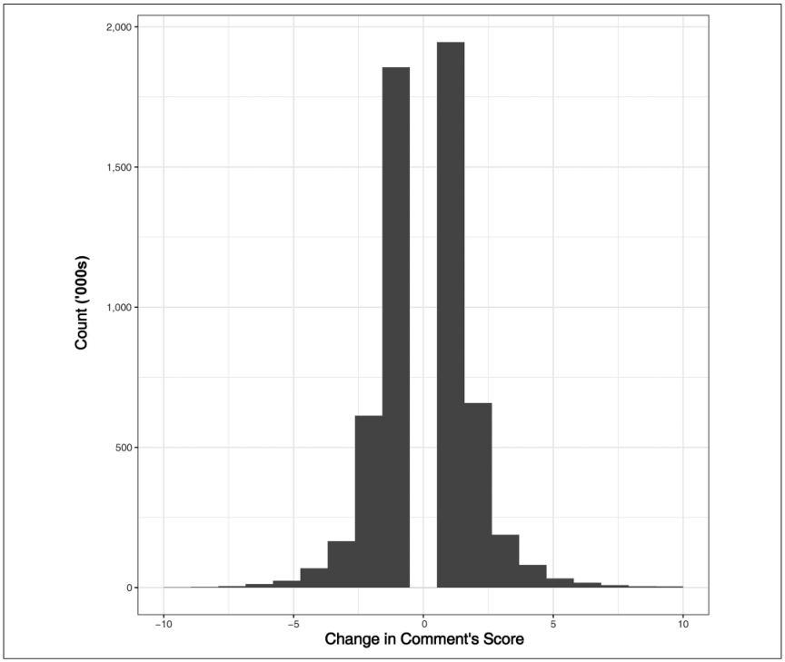

NOTE: figure/graphic rendered as an image from the PDF; its content is not machine-readable text. Caption (if any) follows as the next block.

#### Correlation Between Feedback and Incidence

The average probability that a user creates at least one comment on any given day is .29. Figure 2 shows the average daily probability of commenting based on whether a user’s comment karma decreased, increased, or stayed the same in the previous day. These data show that, on average, negative (and positive) feedback are associated with an increased propensity to comment, relative to no feedback.

While this pattern might suggest a causal relationship between receiving feedback and subsequent posting behavior, there are alternative explanations. First, users differ in their intrinsic, timeinvariant propensity to post. For instance, highly motivated users may both post more and receive more feedback. We can control for time-invariant, user-level heterogeneity with user fixed effects.

Second, the propensity of users to create content could vary over time. For example, users may be more likely to post on weekends but are also more likely to receive more peer feedback due to increased user activity. We can control for such temporal trends that are shared by all users with time- (day-) level fixed effects.

Finally, even after accounting for cross-sectional and temporal heterogeneity, there may be confounding factors that vary over time within a user. We can control for the obvious ones, such as whether the user posted in the previous day t −1 (e.g., users who post more recently are more likely to get feedback and may also be more likely to post again), karma levels (e.g., users with better reputations may be more active and receive more feedback), and the absolute amount of feedback

Figure 1. Distribution of Feedback Received by Comments. Notes: This figure displays the distribution of the day-to-day change in score across all comments, conditional on there being a change in score (i.e., receiving any feedback).

772 Journal of Marketing Research 63(4)

Page 7

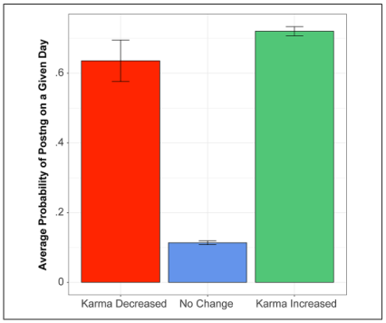

NOTE: figure/graphic rendered as an image from the PDF; its content is not machine-readable text. Caption (if any) follows as the next block.

(which may correlate with comment topics and posting propensity). As will become evident subsequently, this particular set of controls is important for our identification strategy.

We examine whether the correlations between feedback and incidence persist after controlling for cross-sectional and temporal heterogeneity and the aforementioned variables (e.g., whether the user posted on the previous day, karma levels, and absolute amount of feedback) that change within-user over time. To this end, we estimate the following linear regression:

yit = β11{NegativeFdbcki,t−1} + γ11{PositiveFdbcki,t−1}

+ αi + αt + X<sup>′</sup>Δ + ϵit, (1)

where we consider two dependent variables:

{Commentit}, which is an indicator for whether the user i posts a comment on day t, and log(NumCommentsit), which is the logged number of comments i posts on day t.<sup>10</sup> The variable

{NegativeFdbcki,t −

{PositiveFdbcki,t −1} is indicator for whether the comment karma increased between t−2 and t−1 (i.e., Karmai,t −2<Karmai,t −1). We include individual and calendar day fixed effects, αi and αt. X denotes a matrix of controls, which include whether the user commented on the previous day (

{Commenti,t −1}), i’s karma on the previous day (Karmai,t−1, Karma<sup>2</sup>

i,t−1<sup>).</sup> We report the estimates of Equation 1 in Table 2. For both dependent variables, these results reinforce the previous findings that receiving either positive or negative feedback is

associated with a higher propensity to post (relative to receiving no feedback) in the subsequent period.

#### Identification Strategy

Despite controlling for individual- and time-level differences and user experience over time, there may still remain additional sources of omitted variable bias in the form of unobserved shocks that vary within individuals over time. Such omitted variables can contaminate the causal effect estimates if they are correlated with the feedback that a user receives as well as their subsequent posting behavior. We consider four types of omitted variables:

• Change in content. An individual who becomes more interested in a topic (e.g., politics) may post more about it. If the topic is controversial, this can attract more negative feedback. • Content-level shocks. Suppose an individual posts about a topic (e.g., abortion) at time t, and a political event (e.g., the overturning of Roe v. Wade) occurs at t + 1. This event can impact the feedback the individual receives on their post made at time t, as well as their propensity to post after t + 1. • Visibility. Posts that have high visibility (e.g., better position on the page) may receive more feedback. The high visibility of the post might also encourage the focal user to produce more content in the future. • Replies from other users. Replies from other users, which we do not observe, can impact both subsequent UGC and correlate with feedback. For instance, negative feedback for a post can correlate with more combative replies.

To address the concern about such omitted variables, we exploit the idea that for a given level of feedback, changes in karma are likely to be more salient when karma crosses

Table 2. Correlation Between Feedback and Incidence.

[output not shown]

NOTE: table converted from PDF layout to HTML text; cell boundaries are reconstructed. See PDF if exact alignment matters.

Notes: This table displays the OLS regression estimates of Equation 1. Standard errors, in parentheses, are clustered at the user level. p-Values are in square brackets. Coefficient estimates for the controls are omitted for readability. Table WB.1 in the Web Appendix reports all estimates.

10 We add 1 to all logged variables.

Deolankar et al. 773

Page 8

certain thresholds. A similar approach is used by Fong and Hunter (2022). Consider a scenario A in which a user’s karma decreases from 104 to 100, and a scenario B in which their karma decreases from 103 to 99. Despite receiving the same amount of feedback in both scenarios (−4), we assume that the negative feedback is likely to feel more salient to the user in scenario B than in scenario A because of left-digit bias. Left-digit bias is a well-documented phenomenon in which individuals tend to pay more attention to the leftmost digits when evaluating numbers (Bizer and Schindler 2005). This bias has been documented across a variety of contexts, such as retail prices (Anderson and Simester 2003; Strulov-Shlain 2022; Thomas and Morwitz 2005), car mileage (Lacetera, Pope, and Sydnor 2012), and the quality of donor kidneys (Husain, King, and Mohan 2021). Therefore, our identifying assumption is that controlling for the magnitude of feedback and karma, a leftdigit change in karma is uncorrelated with unobservables that impact posting incidence.

[figure not shown]

NOTE: figure/graphic rendered as an image from the PDF; its content is not machine-readable text. Caption (if any) follows as the next block.

The last two types of omitted variables—visibility and replies from others—deserve a more nuanced discussion. We conjecture that visibility is unlikely to correlate with changes in the left digit of the user’s karma because a comment’s visibility depends on the upvotes and downvotes of the comment, rather than the user’s aggregate karma.<sup>11</sup> Additionally, although feedback and visibility could be correlated with the author’s karma (e.g., those with higher karma might post better content, which gets fewer downvotes and more visibility), the effect of score on position is likely to be smooth rather than exhibit a discontinuous jump at karma left-digit thresholds.<sup>12</sup>

We also conjecture that the text replies a user receives are unlikely to be correlated with the left digit of the user’s karma. For correlation to be present, others’ commenting behavior would have to change when the left digit of the author’s karma changes. This requires other users not only to view the author’s karma but also to keep track of the author’s karma’s left digit (and change their commenting behavior afterwards). This is unlikely, because when viewing a comment, the author’s karma is not prominently displayed to others. Viewers must click or hover over the username to see it. Thus, we assume that, controlling for amount of feedback and the user’s karma, the occurrence of comment replies and visibility changes are unlikely to correlate with shifts in a user’s karma’s left digit.

Two additional assumptions underpin this identification approach: (1) a left-digit change enhances feedback salience, and (2) users notice this change. For (1), we rely on the evidence documented in the literature showing that left-digit changes draw more attention. We also perform a placebo test to verify this assumption and discuss this further in the “Robustness Checks” section. For (2), Reddit clearly displays

the user’s own karma (see Figure 3 for an example of how submission and comment karma are displayed), making it more likely that they notice any changes. Nevertheless, we cannot guarantee that all users observe when their own karma’s leftdigit changes. Therefore, we can interpret these effects as intent-to-treat (ITT) effects.

Given this identification strategy, we estimate the following linear regression:

yit =β11{NegativeFdbcki,t−1} + β2(1{NegativeFdbcki,t−1}

× 1{LDCi,t−1}) + γ11{PositiveFdbcki,t−1}

+ γ2(1{PositiveFdbcki,t−1} × 1{LDCi,t−1}) + αi + αt + X<sup>′</sup>Δ + ϵit.

(2)

Similar to Equation 1, the dependent variables are whether the user posts a comment and the logged number of comments on day t. The variable

{LDCi,t −1}is an indicator for whether the leftmost digit of user i’s karma at day t −1 is different from the leftmost digit at t −2. Although not the focus of our paper, the identification strategy also allows us to estimate the effect of salient positive feedback. For completeness, we estimate the coefficients for the main effect of positive feedback and its interaction with a left-digit change (γ1, γ2).

The matrix X includes number of comments in the previous day (log(Commenti,t −1)), i’s karma on the previous day (Karmai,t−1, Karma<sup>2</sup>

The term β1 represents the change in a user’s propensity to post when they receive negative feedback in the previous period. However, as discussed previously, we cannot interpret this as a causal effect. Rather, the coefficient of interest is β2, which corresponds to the causal effect of salient negative feedback (i.e., associated with a left-digit decrease in karma) on subsequent content creation. An estimate of β2 > 0 would indicate that users are more likely to comment if they received negative feedback and the left digit of their karma changes (i.e., the decrease in karma is more salient) relative to when

Figure 3. Example of How Karma Is Displayed.

11 This has been true as of 2009. Munroe (2009) provides further information about Reddit’s comment-sorting algorithm. 12 We also control for the correlation between the user’s karma and propensity to comment with user fixed effects and their karma.

774 Journal of Marketing Research 63(4)

Page 9

they received negative feedback and the left digit of their karma did not change (i.e., the decrease in karma is less salient).

How often do left-digit changes occur? Conditional on positive feedback, the left digit changes in 5.8% of observations, and for negative feedback, it changes in 3.8% of observations. In total, there are 11,867 observations from 5,575 unique users (out of 17,525) with a left-digit change. We illustrate the identifying variation in Figure WA.4 in the Web Appendix, which compares posting incidence between two groups of users who received negative feedback: those who experienced a left-digit change in their karma versus not. This figure shows that posting incidence increases for those who experience a left-digit change.

#### Results

We present the estimates of Equation 2 in Table 3. The coefficient for the interaction between receiving negative feedback (i.e., a decrease in karma) and a left-digit change is positive and statistically significant (Column 1). Thus, users are more likely to comment when negative feedback is felt more saliently than in instances when it is less salient. The coefficient for the interaction between receiving positive feedback and a left-digit change is also positive and statistically significant. This implies that receiving either positive or negative feedback increases the production of UGC.<sup>13</sup>

Our identification strategy hinges on the idea that feedback causing a left-digit change is more salient than feedback that does not. We verify this idea by conducting a placebo test wherein we create a “LDC Placebo” treatment, which equals 1 if the user’s karma gets close (within five points) to a leftdigit change but the left digit does not actually change. The effect of the “LDC Placebo,” presented in Section C.1 of the Web Appendix, is not statistically significant, which supports the idea that the effect of negative feedback is stronger when there is an actual change in the left digit.

#### Robustness Checks

We address four potential concerns with the estimates in Table 3. The first concern is that the average effect may be driven by outliers—users who receive a large amount of feedback, such as when their comment becomes viral. These cases are more likely to involve a left-digit change in karma

and increased posting. To address this, we restrict our analysis to instances where the magnitude of the feedback (both positive and negative) is within the first tercile.<sup>14</sup> The results, reported in Table 4, show that our average effect is not driven by outliers.

The second concern is that users closer to the threshold anticipate a left-digit change and behave differently than those further away. Such a relationship would imply that the user’s distance from the threshold could be correlated with them experiencing a left-digit change and also their propensity to post. Although we control for the distance from the threshold in Equation 2, we can further address this concern by limiting the sample to only those who are further from the threshold: observations where karma’s distance to threshold is in the second or third tercile.<sup>15</sup> The results in Table 5 show that the effects persist in this subsample.

The third concern is that left-digit changes are more likely when karma has fewer digits. That is, the amount of feedback required to induce a left-digit change is greater when the karma has more digits. Although we control for the magnitude of feedback in our analysis, the parameterization might not fully capture the intricate relationship between the magnitude of the feedback and subsequent posting behavior. Therefore, we include fixed effects for the number of digits in Karmai,t −2. We find that the effects, reported in Table WB.6 in the Web Appendix, are robust to the inclusion of these fixed effects.

A related issue is that our average effect may be driven by users with lower karma scores, since those users are more likely to have left-digit changes. If users with different digits

Table 3. Effect of Feedback on Incidence.

[output not shown]

NOTE: table converted from PDF layout to HTML text; cell boundaries are reconstructed. See PDF if exact alignment matters.

Notes: This table displays the OLS regression estimates of Equation 2. Standard errors, in parentheses, are clustered at the user level. p-Values are in square brackets. Coefficient estimates for the controls are omitted for readability. Table WB.2 in the Web Appendix reports all estimates.

13 It is also possible that the feedback on day t −2 impacts behavior on t + 1, t + 2, …, in addition to t. We focus on effects on t because it reduces the risk that the measured effect is contaminated by other factors. That is, long-term effects are typically more difficult to measure precisely because many other factors can influence longer-term posting behavior. Nevertheless, we estimated the effect over a longer time window, where we look at the effects on t + 1 and t + 2 in response to a left-digit change in karma on t −1. We find statistically significant positive effects of salient negative feedback on t + 1, as well as t, but the effect becomes statistically insignificant on t + 2. These estimates are available upon request. We thank an anonymous reviewer for suggesting the investigation of the long-term effects of salient feedback.

14 For observations with feedback, the first tercile is 21. 15 The 33rd percentile of distance to threshold is 15.

Deolankar et al. 775

Page 10

in their karma respond differently to the left-digit change, the average effect might not paint the entire picture. We investigate this potential heterogeneity by performing the analysis for subsamples of users with different numbers of karma digits. Our results in Table WB.7 in the Web Appendix

show that the positive effect of a left-digit decrease is consistent across observations with two, three, four, and five digits of karma.

The last potential concern is that our effect of interest, the coefficient of the interaction term between receiving negative feedback (

{NegativeFdbcki,t −1}) and a left-digit change (

{LDCi,t −1}), might be biased because

{NegativeFdbcki,t −1} is endogenous. Nizalova and Murtazashvili (2016) consider this problem and demonstrate that under certain conditions, the estimated coefficient of the interaction between an exogenous variable (whether the left digit changes) and an endogenous variable (whether the user receives negative feedback) is consistent even if other estimates may be biased. Translating the conditions in Nizalova and Murtazashvili into our setting, if (1)

{NegativeFdbcki,t −1} is independent of 1{LDCi,t −1} and (2) f (

{NegativeFdbcki,t −1}|

{LDCi,t −1},ϵ)= f (

{NegativeFdbcki,t −1}|ϵ), then the estimate of the interaction is consistent.<sup>16</sup> In words, the coefficient of the interaction term between negative feedback and whether the left digit changes is consistent if a left-digit change is not informative of whether the feedback is positive or negative. This is true in our setting because a left-digit change can occur in either direction.<sup>17</sup> In Web Appendix D, we report Monte Carlo simulations that demonstrate that the coefficient of the interaction between an endogenous and an exogenous term, using a data-generating process like ours, is consistently estimated.

As another robustness check, we estimate the regression only for observations where the user receives negative feedback, which removes the need for the interaction with the endogenous variable. Here, the coefficients can be interpreted as conditional on negative feedback. The estimates, reported in Table 6, are similar in magnitude to interactions reported in Table 3.

#### Effects on Where Users Post

We had conjectured that negative feedback could lead to the formation of echo chambers if individuals stop contributing content in the specific community where they received negative feedback. Although the finding that negative feedback increases average incidence might suggest that it doesn’t contribute to echo chamber formation, that conclusion may be premature. The overall positive effect does not eliminate the possibility that negative feedback discourages posting within the specific community where it occurred, as users may reduce activity in that community while increasing it elsewhere. To explore

Table 4. Effect of Feedback on Incidence: Robustness to Outliers in Feedback Magnitude.

[output not shown]

NOTE: table converted from PDF layout to HTML text; cell boundaries are reconstructed. See PDF if exact alignment matters.

Notes: This table displays the OLS regression estimates of Equation 2 but estimated on the sample where |Fdbck| ≤33rd percentile. Standard errors, in parentheses, are clustered at the user level. p-Values are in square brackets. Coefficient estimates for the controls are omitted for readability. Table WB.4 in the Web Appendix reports all estimates.

Table 5. Effect of Feedback on Incidence: Robustness to Distance from Threshold.

[output not shown]

NOTE: table converted from PDF layout to HTML text; cell boundaries are reconstructed. See PDF if exact alignment matters.

Notes: This table displays the OLS regression estimates of Equation 2 but estimated using the sample where DistFromThreshold > 33rd percentile. Standard errors, in parentheses, are clustered at the user level. p-Values are in square brackets. Coefficient estimates for the controls are omitted for readability. Table WB.5 in the Web Appendix reports all estimates.

16 We refer readers to Nizalova and Murtazashvili (2016) for the proofs. 17 One might be concerned that while the left digit of karma changing is not informative of the direction of the feedback, it is informative that the user receives any feedback. To this end, we conduct a robustness check in which we consider only observations where feedback is received. We find that the estimates are robust; the main effect of the left-digit change is positive and statistically significant, indicating that a left-digit change increases posting incidence, regardless of direction. The difference in the effect of a left-digit change is not statistically different between receiving positive and negative feedback. The estimates are reported in Table WB.8.

776 Journal of Marketing Research 63(4)

Page 11

this, we examine whether the increased posting after negative feedback occurs in (1) the same submissions and communities in which they receive the negative feedback and/or (2) different communities. Of these, a decrease in (1) would suggest that the overall increase in a user’s propensity to post upon receiving negative feedback was driven by an increase in (2). Under such a scenario, negative feedback might have deterred users from staying engaged in the same space and therefore exacerbated the formation of echo chambers. We test which pathway(s) contribute to the overall effect that we documented in Table 3 by considering subsequent commenting activities by users in (1) the same submission, (2) the same subreddits but different submissions, and (3) different subreddits. Of these, (1) and (2) capture whether a user stays engaged in the same space (submission or subreddit, respectively) where they received negative feedback, while (3) reflects their propensity to stay active on the platform but in a different space.

To implement this idea empirically, we need to link feedback to specific comments posted by a user. Since 99.7% of feedback occurs within a week of comment creation, we focus on comments made within a week before a negative karma change to identify likely sources of that feedback. This time window allows us to isolate the corresponding content that received the negative feedback. Of course, if this set has multiple comments, we cannot uniquely identify the specific comment(s) that led to the decrease in karma.

We present the results from this analysis in Table 7. The dependent variable in Column 1 is whether the user creates a comment in the same submission as the ones they commented on in the prior seven days.<sup>18</sup> In Column 2, the dependent variable is whether the user comments in at least one of the subreddits in which they commented in the previous seven days. We do not find a statistically significant effect of negative feedback on a user’s propensity to stay engaged in the same space. This

implies that we do not find evidence of negative feedback exacerbating echo chambers. While users are more likely to engage in different subreddits than the ones they commented in previously (Column 3), there is no evidence that users are less likely to engage in the same space as the ones they commented in previously (Columns 1 and 2). Therefore, the average increase in commenting activity is due to engagement in different spaces rather than the ones in which they received the negative feedback.

#### Effects on Intensity of the Content

In this section, we assess how receiving negative peer feedback changes the strength of opinions expressed by an individual. We consider this aspect of posting behavior because it has potential implications for polarization (Asker and Dinas 2019). Therefore, our main outcome of interest is the intensity of the content’s sentiment. To illustrate, we consider the statement “Blue is a nice color” to be less intense (and potentially less polarizing) than “Blue is the best color.” We describe how we quantify the intensity of a comment in the “Measuring Intensity” section.

While assessing whether and how receiving negative peer feedback changes the intensity of the content, we assume that the impact would be realized only for the topic toward which such feedback is directed. For example, if a user receives negative feedback on a comment that mentions topic A, we expect this feedback to influence their future mentions of topic A but not of an unrelated topic B. This assumption implies we should conduct our analysis at the topic level. However, on Reddit, feedback is given for a comment, rather than for a specific topic within a comment; if a user receives downvotes for a comment that mentions topics A and B, we cannot determine whether the downvotes are directed toward topic A, topic B, or both. Consequently, we focus on how the feedback toward a focal comment affects the intensity of a user’s subsequent comments on the same topic(s). Thus, in this section, we consider feedback at the comment level. We define the feedback a comment receives in period t as the change in the focal comment’s score between t and t −1 (i.e., the feedback is negative in t if the comment’s score decreases from t −1 to t).

#### Measuring Intensity

We use Google’s Natural Language API to measure the intensity of text. The API uses entity sentiment analysis, which is a natural language processing task that combines named-entity recognition and sentiment analysis (Do et al. 2019; Nazir et al. 2020; Schouten, Frasincar, and Dekker 2016). This machinelearning model identifies entities (topics) in text and quantifies the sentiment’s direction and strength toward each entity. As defined by Google’s Natural Language API, an entity “represents a phrase in the text that is a known entity, such as a person, an organization, or location.”<sup>19</sup>

Table 6. Effect of Feedback on Incidence: Conditional on Receiving Negative Feedback.

[output not shown]

NOTE: table converted from PDF layout to HTML text; cell boundaries are reconstructed. See PDF if exact alignment matters.

Notes: This table displays the OLS regression estimates of a specification similar to Equation 2. The differences are that there is no interaction term between the left-digit change and the direction of the feedback, and the sample consists only of observations where

{NegativeFdbcki,t −1} = 1. Standard errors, in parentheses, are clustered at the user level. p-Values are in square brackets. Coefficient estimates for the controls are omitted for readability. Table WB.9 in the Web Appendix reports all estimates.

18 The results are also robust to using a three-day window. We do not report these results here but can provide them upon request.

19 For a more detailed definition of “entity,” see https://cloud.google.com/ natural-language/docs/reference/rest/v1/Entity (accessed January 2023).

Deolankar et al. 777

Page 12

For each entity, we observe three attributes: salience, sentiment score, and magnitude score. Salience, ranging from 0 to 1, quantifies the importance of the entity in the text. More important entities receive a higher salience score. The sentiment score, ranging from −1 to +1, describes the overall emotional leaning toward an entity. Scores between 0 and 1 indicate that the sentiment is positive, while scores between 0 and −1 indicate a negative sentiment. The sentiment score can also capture the strength of the emotion; the closer the score is to 1 (−1), the more positive (negative) the sentiment. Scores closer to 0 can mean either that the sentiment toward the entity is not intense or that both positive and negative sentiments are present in the text, thus canceling each other out. The magnitude score, ranging from 0 to ∞, measures the overall strength of the sentiment toward the entity, regardless of its direction. Figure 4 provides examples of the classification of entities and sentiment in our data, and Figure 5 displays the histograms of the sentiment and magnitude scores of the entities in our sample. Entities with higher magnitude scores also tend to have sentiment scores closer to −1 or 1. In our sample, the correlation between the magnitude score and the absolute value of the sentiment score is .74.<sup>20</sup> We refer to entities that have a higher magnitude score or a higher absolute value of the sentiment score as more intense.

#### Correlation Between Feedback and Intensity

Recall that we seek to understand how feedback on a comment impacts the intensity in subsequent comments by the user that mention the same entities. Next, we describe how we construct our variables of interest before presenting the correlations between feedback toward the focal comment and the intensity of the “next mentions.”

Let c denote the original comment, and t(c) denote the day that c is created. Ec = {e1, e2, …, eE} is the set of entities in c, and let <sup>˜</sup>Ec ⊂Ec be a set of all “salient” entities in Ec. We define an entity as “salient” if the entity’s salience is greater than or equal to the median, .052.<sup>21</sup> We include this restriction on salience because we expect that feedback is more likely to be directed at the more salient entities in a comment. We denote sec and mec to be the sentiment score and magnitude score of entity e in comment c, respectively.

The outcome of interest is the intensity of the “next mention” of salient entities in c. To illustrate how we define a “next mention,” consider a comment c created by user i on day t with two salient entities, a and b. Suppose user i creates another comment c<sup>′</sup> on day t + 2 that mentions either a or b, which is the first day after t that user i comments about a or b. Comment c<sup>′</sup> is then the “next mention.” If c<sup>′</sup> mentions only a (or only b), the outcome is the intensity (e.g., absolute sentiment) toward a (or b). If both are mentioned, the outcome is the average intensity toward a and b. Alternatively, if user i creates another comment c<sup>′′</sup> on the same day as c<sup>′</sup> that also mentions a

Table 7. Effect of Feedback on Incidence: Where Users Post.

[output not shown]

NOTE: table converted from PDF layout to HTML text; cell boundaries are reconstructed. See PDF if exact alignment matters.

Notes: This table displays the OLS estimates of a specification similar to Equation 2. The dependent variables are indicators for whether the user creates a comment in the same submission they commented on in the previous seven days, in the same subreddit(s) but different submission(s) in the previous seven days, and in a different subreddit than the one(s) they commented on in the past seven days, respectively. Standard errors, in parentheses, are clustered at the user level. p-Values are in square brackets. All coefficient estimates are reported in Table WB.10 in the Web Appendix.

20 There may be instances in which the sentiment score is 0 but the magnitude score is not. In cases where the sentiment score is 0, the magnitude score can help distinguish between neutral content and conflicting emotions: A sentiment score of 0 and a magnitude close to 0 indicates that the text does not contain strong language, while a sentiment score of 0 and a high magnitude indicates the presence of both positive and negative opinions.

21 The mean is .17. We test for robustness to alternative thresholds in Tables WE.1 and WE.2 in Web Appendix E.

[figure not shown]

NOTE: figure/graphic rendered as an image from the PDF; its content is not machine-readable text. Caption (if any) follows as the next block.

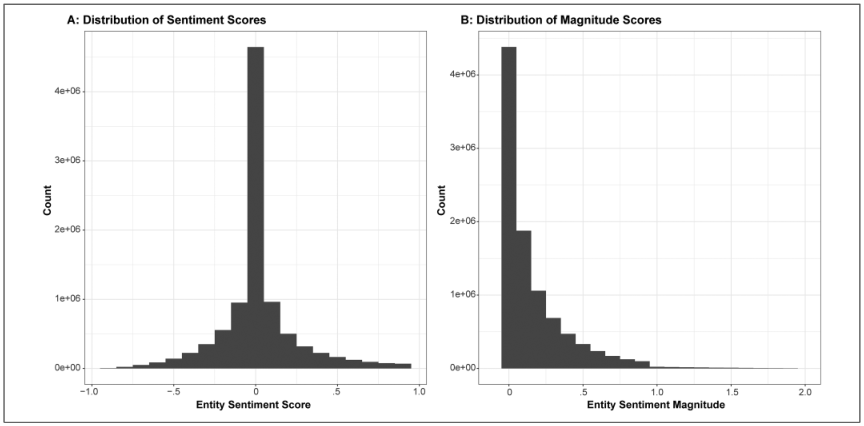

NOTE: figure/graphic rendered as an image from the PDF; its content is not machine-readable text. Caption (if any) follows as the next block.

where N = Σc′∈C<sup>′</sup> Σe∈Ec′ 1{e ∈<sup>˜</sup>Ec}, and C<sup>′</sup> is the set of comments that are (1) posted on day t<sup>′</sup> such that t<sup>′</sup> is the first day after t(c) that i mentions any of the entities in the original comment c, and (2) contain at least one entity in <sup>˜</sup>Ec. In words, C<sup>′</sup> is the set of comments that contain the first “next mention(s)” of the salient entities in the original

comment. Because 99.7% of all feedback is received within the first week of posting, we restrict our main analysis to “next mentions” that occur within a week of the original comment.<sup>22</sup>

To measure the correlation between feedback and subsequent content intensity, we estimate the following linear regression:

Figure 4. Examples of the Entity and Sentiment Classifications.

Figure 5. Histograms of Sentiment and Magnitude Scores. Notes: These histograms plot the distributions of the sentiment and magnitude scores for all entity mentions in our corpus. Each observation is an entity.

22 We test for robustness to alternative time windows in Tables WE.3 and WE.4 in Web Appendix E.

(5)

In this specification, i indexes the user, and c indexes the original comment. We use two measures of intensity as outcomes: |s<sup>′</sup>icτ|, the absolute value of the average sentiment score, and log (m<sup>′</sup>icτ), the logged magnitude score, as described in Equations 3 and 4. The subscript τ is the number of days between the original comment and the next mention. For instance, if c is posted on day t and the next mention occurs on day t + 2, then τ = 2. The variable

{NegativeFdbckicτ} is an indicator for whether comment c receives negative feedback τ days after c is created; this term equals 1 if Scoreicτ < Scoreicτ −1. Similarly,

{PositiveFdbckicτ} = 1 if Scoreicτ > Scoreicτ −1. Because we know when the comment’s score is collected and the time of each comment, we can ensure that all next mentions occur after we observe the comment’s feedback.

The terms β1 and γ1 capture the correlation between intensity and negative and positive feedback, respectively. We expect that the extent of moderation depends on the intensity of the original comment, as moderation can occur to a greater extent for extreme comments. Therefore, we include the interaction between the indicator for negative feedback with the average intensity of the original comment. For completeness, we also include the interaction for the average intensity with the indicator of positive feedback. We use the same measure of intensity for the original comment as the next mention. For example, if the dependent variable is based on the absolute sentiment score of the next mention (|ˉs<sup>′</sup>ic|), then Intensityic is also measured by the absolute sentiment score (|sic|).<sup>23</sup> β2 and γ2 indicate the extent that the intensity of the original comment is associated with the effect of negative and positive feedback, respectively.

We include fixed effects for each user i (because users who post more intense content may get more feedback); the calendar date of the “next mention” (because the intensity of content may vary across days); τ, the number of days between when c is created and the first next mention (because intensity toward an entity may change over time); and r(c), the subreddit of the original comment (because different subreddits may inherently vary in the intensity of content). As in Equation 2, we also control for the original comment’s score on the previous day (Scoreicτ−1, Score<sup>2</sup>

τ(|Feedbackicτ|, Feedback<sup>2</sup>

icτ<sup>)</sup> <sup>in</sup> <sup>matrix</sup> <sup>X</sup><sup>ic</sup><sup>τ</sup><sup>.</sup> <sup>The</sup> <sup>matrix</sup> <sup>X</sup> also includes the intensity of the original comment, averaged over all salient entities, which controls for correlations in intensity across mentions (i.e., a user who is intense about topic a may also be more intense the next time they mention topic a). In this comment-level data set, 482,900 comments (31%) experience negative feedback at least once, and 515,468 comments (33%) experience positive feedback at least once within seven days of comment creation.

Table 8 reports the ordinary least squares (OLS) estimates of Equation 5. We find that the main effects of negative feedback (the coefficient of

{NegativeFdbckicτ}) is positive, but its interaction with the sentiment of the original comment (the coefficient of

{NegativeFdbckicτ} × Intensityic) is negative and statistically significant. This suggests that negative feedback is associated with moderation of intensity in subsequent comments if the original comment was more extreme. We see a similar intensity moderation for positive feedback.

#### Identification Strategy

Many of the same endogeneity challenges that arise when measuring effects on incidence also apply when measuring effects on intensity. In the Roe v. Wade example, the unobserved increased salience of the specific topic of abortion rights would impact both the direction of the feedback and the

Table 8. Correlation Between Feedback and Intensity of Subsequent Content.

[output not shown]

NOTE: table converted from PDF layout to HTML text; cell boundaries are reconstructed. See PDF if exact alignment matters.

Notes: This table presents the OLS estimates of Equation 5. Intensity is measured by the absolute value of the sentiment score and logged magnitude score in Columns 1 and 2, respectively. Standard errors, in parentheses, are clustered at the user level. p-Values are in square brackets. Coefficient estimates of the score and feedback are omitted for readability. All coefficient estimates are presented in Table WB.12 in the Web Appendix.

23 sic is the average of the sentiment scores of all salient entities in comment c, weighted by the entity’s salience: sic =

reweighted salience of all entities in <sup>˜</sup>Ec such that

average of the magnitude score of all salient entities, also weighted by the entity’s salience.

language used toward that topic in future mentions. To address this, we apply an identification strategy similar to the approach used previously. We rely on the idea that changes in the score of a comment (the difference in upvotes and downvotes) are more salient if the score crosses a certain threshold. Recall that we conjecture that feedback is likely to impact future mentions of the entity (or entities) toward which the feedback is directed. Therefore, our unit of observation is a comment. Unlike karma, comments’ scores tend to be smaller; in our data, 86% of comments have a score between −10 and 10. This implies that we cannot use the left digit as the threshold at which feedback becomes more salient. As a result, we use a sign change as the threshold.

Holding the amount of feedback constant, we assume that changes in score are likely to be more salient when the sign changes. For example, we assume that negative feedback is more salient when a comment’s score drops from 2 to −1 than when its score drops from 4 to 1, despite both receiving a feedback of −3. In our data, within the first seven days since comment creation, 10,389 comments (.7%) experience a negative sign change at least once, and 8,435 comments (.5%) experience a positive sign change at least once. We conduct a placebo test to check the validity of this assumption that feedback that is associated with a sign change is more salient. The details of this placebo test can be found in Section C.2 of Web Appendix C.

There are two potential concerns with this identification strategy. First, it is possible that a comment’s visibility depends on its score. Therefore, our estimates of the effect of more salient negative feedback are biased if a comment’s visibility, proxied by rank, disproportionately changes when its score crosses zero. As discussed previously, visibility can directly impact the user’s subsequent content. Because Reddit has not recently disclosed its comment ranking algorithm, we are unable to definitively rule this out. However, in the context of submissions, Moehring (2023) does not observe discontinuities in the effect of the post’s score on rank. While this gives us more confidence in our identification strategy, we acknowledge that comments may use a different ranking algorithm.

The second potential concern with our identification strategy is that the quantity and/or content of the text replies made by other users (which we do not observe) to the author’s comment correlates with the comment’s score’s sign change. This could happen if users are more likely to respond with provocative replies when a comment is controversial, which may coincide with the score crossing zero. In that case, we cannot identify whether the subsequent change in the author’s intensity is due to the negative feedback in the form of downvotes or other users’ replies. To test whether this occurs, we use a smaller dataset where we can observe other users’ replies. We do not find any correlation between the quantity and content of the replies and the occurrence of score changes in the author’s comment (Web Appendix F).

We implement this identification strategy by estimating the following linear regression:

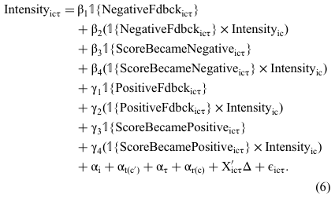

NOTE: complex table shown as an image of the PDF; the text below is a rough machine extraction and may be mis-aligned.

**extracted text (unreliable layout)**

This regression is identical to Equation 5, with the exception of four additional variables:

{ScoreBecameNegativeicτ},

{ScoreBecamePositiveicτ}, and their interactions with the intensity of the original comment. The variables

{ScoreBecameNegativeicτ} and

{ScoreBecamePositiveicτ} are indicators for whether the score of the original comment changes from greater than 0 to less than or equal to 0 or changes from less than or equal to 0 to greater than 0 from day τ −1 to day τ, respectively. Given our identification strategy, the coefficients of interest are β3 and β4, which correspond to the effect of a salient increase in negative feedback. We illustrate the identifying variation in Figure WA.5 in Web Appendix A. This figure compares the intensity, as measured by the |sentiment| and magnitude of subsequent content, for comments that switch signs, conditional on the score decreasing.

Recall that a comment’s score is subject to measurement error due to Reddit’s score “fuzzing.” This means our indicator for whether the score changes signs is prone to misclassification error. We argue that fuzzing biases our estimates of β3 and β4 toward zero for the following reasons. Aigner (1973) demonstrates that if the error is nondifferential (i.e., conditional on the true value of the misclassified variable, the errors are independent of the outcome variable), the estimated coefficient for the misclassified variable is biased toward zero. In our setting, this means that in order for the error to be nondifferential, the content of the users’ subsequent comments must be uncorrelated with the likelihood that we “misobserve” whether the sign changes. We conjecture that it is unlikely for this measurement error to be correlated with the content of the user’s subsequent comment. This is because the fuzzing mechanism employed by Reddit implies that users who see the same comment at different times are likely to observe different values of scores (and the sign change therein). Since the observed intensity of the subsequent comment will not change from user to user, we argue the nondifferential measurement error assumption is likely to hold. As such, our coefficient estimates involving whether the score changes signs can be interpreted as lower bounds on the true effects. We also conduct a Monte Carlo simulation in which we demonstrate that the estimated coefficients of interest—whether the score

becomes negative and its interaction with the sentiment of the focal comment—when using the fuzzed score are closer to zero than the estimated coefficients when using the true scores. Web Appendix G describes the results from Aigner (1973) and our simulation in detail.

#### Results

We report the estimates of Equation 6 in Column 1 of Table 9. The main effect of the term

{ScoreBecameNegativeicτ} is positive and statistically significant when intensity is measured by the absolute value of the sentiment score, but not when measured by the magnitude score. This implies that when the intensity of the original comment is zero, more salient negative feedback increases the absolute value of the sentiment score. However, the negative coefficient of the interaction between

{ScoreBecameNegativeicτ} and Intensityic is statistically significant for both measures. This means that negative feedback causes moderation when the original comment is intense. We do not find a statistically significant effect of positive feedback that is accompanied by a sign change.

Figure 6 illustrates the effect of negative feedback based on the estimates in Table 9. This figure plots the predicted intensity (i.e., the absolute value of the sentiment score, |s<sup>′</sup>c|) of the next mention as a function of the intensity of the original comment (|sc|). In this figure, we hold the amount and direction of the feedback fixed. The solid line represents the predicted intensity of the next mention when the comment’s score does not change signs, while the dashed line represents the predicted intensity when comment’s score changes signs.

Figure 6 shows that when the intensity of the original comment is zero, the sentiment of the next mention is higher when the score became negative than when the score did not become negative. This suggests that salient negative feedback increases the intensity of the subsequent comment if the original comment was not intense. However, as intensity of the original comment increases (to greater than .17), the countervailing negative effect of the interaction between

{ScoreBecameNegativeicτ} and |sic| moderates the intensity of subsequent posts. To put this in perspective, about 33% of the comments in our sample have an average absolute sentiment score greater than .17. Therefore, this moderating effect of negative feedback is prevalent in our sample. We plot the analogous results using the logged magnitude score as the measure of intensity and find similar results (Figure WA.7 in Web Appendix A).

#### Robustness Checks

A potential concern with the above analysis is that a sign change in scores is more likely to occur when the magnitude of feedback is large. The magnitude of the feedback can directly influence the intensity of subsequent content, thereby threatening our identification strategy. In our specification in Equation 6, we address this concern by including a parametric function of the magnitude of the feedback as a control. However, it is still conceivable that the parametric specification does not fully

capture the direct relationship between the magnitude of feedback and the intensity of subsequent content. To account for this, we consider a subsample of comments with the absolute value of feedback to be three or less. The estimated coefficients for this subsample, reported in Columns 3 and 4 of Table WB.13 in Web Appendix B, are similar to those presented from the full sample (Table 9), suggesting that our estimates are not driven by unobserved factors that correlate with large amounts of feedback.

We also conduct the following robustness checks around sample definitions. Recall that our intensity analysis focused on “salient” entities, which have salience scores above the sample median. The idea behind this approach is that since our dependent variable is the intensity of the subsequent comment when the same entity is mentioned, considering

Table 9. Effect of Feedback on Intensity of Subsequent Content.

[output not shown]

NOTE: table converted from PDF layout to HTML text; cell boundaries are reconstructed. See PDF if exact alignment matters.

Notes: OLS estimates of Equation 6. Intensity is measured by the absolute value of the sentiment score and logged magnitude score in Columns 1 and 2, respectively. Standard errors, in parentheses, are clustered at the user level. p-Values are in square brackets. Coefficient estimates of the score and feedback are omitted for readability. All coefficient estimates are presented in Columns 1 and 2 of Table WB.13 in the Web Appendix.

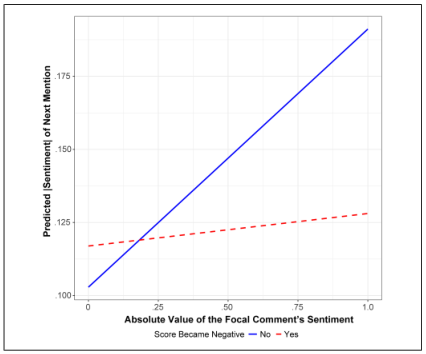

NOTE: figure/graphic rendered as an image from the PDF; its content is not machine-readable text. Caption (if any) follows as the next block.

entities that were not important in the original comment is likely to introduce noise. Although restricting our analysis to entities that have a minimum salience score can reduce this noise, our results can also be sensitive to the choice of this threshold. To verify whether this is the case, we estimate our model using alternative thresholds for salience: 40th percentile and 60th percentile. We find that the results are qualitatively robust (Tables WE.1 and WE.2 in Web Appendix E).

We had also limited the sample to “next mentions” within a week of focal comment creation because 99.7% of all feedback is received within this time window. We verify the robustness of our results to this restriction by considering alternative time windows of four, five, and six days after the focal comment was created. Our substantive insights remain unaltered when we consider alternative time windows (Tables WE.3 and WE.4 in Web Appendix E). We note that when using the magnitude score as the measure of intensity, the effect of the score becoming negative is similar in magnitude as in the full specification but becomes statistically insignificant. In addition, the effects are robust to alternative controls, such as the logged magnitude of feedback and score, and the final score of the comment (as a proxy for comment quality). Web Appendix E details our robustness checks.

#### Heterogeneity Across Topics

We also measure the heterogeneity of the effects across subreddit topics. Controversial topics are of particular interest because they may be more polarizing, emotionally charged, and political in nature. Does negative feedback lead to moderation even in controversial spaces? To explore this, we summarize the

32,048 unique subreddits into 98 topics using a topic model.<sup>24</sup> We then use ChatGPT to classify whether a topic is controversial.<sup>25</sup> Using these classifications, we label each subreddit as controversial or noncontroversial and test whether the effects of negative feedback vary by subreddit type. To this end, we interact the controversial indicator with both whether the score became negative and the intensity of the original comment.

The results (Table 10) show that negative feedback leads to greater moderation (at the 10% level) in controversial subreddits, relative to noncontroversial subreddits, when intensity is measured by the absolute sentiment score. When using the logged magnitude score as the outcome, we observe moderation in both controversial and noncontroversial subreddits. Although the effect is directionally stronger in controversial subreddits, the difference is not statistically significant. Thus, salient negative feedback can reduce polarization by prompting users to moderate their tone, even in contentious spaces.

#### Discussion

Our research was motivated by considerations by prominent social media platforms to introduce negative nonverbal peer feedback, like downvotes and dislikes. This platform design choice has potential implications for the platform as well as for policymakers. From the platform’s perspective, the consideration is how such a change would impact UGC. Our results suggest that negative feedback can (1) increase content creation, (2) encourage users to create content in new spaces, while not discouraging them from creating content in the spaces where they received negative feedback, and (3) moderate the intensity of their opinions. We consider two mechanisms that may underlie these effects: reputation management and learning. Under the reputation management account, users respond to feedback in ways that they believe will enhance their standing on the platform. This is consistent with theories of self-presentation, which describe how individuals strategically manage impressions to project a desired image of themselves (Goffman 1949; Schau and Gilly 2003). Negative feedback may thus activate reputational consideration,

Figure 6. Effect of the Score Becoming Negative on Intensity: Predicted Absolute Sentiment Score. Notes: This figure plots the predicted absolute sentiment score of the next mention for when a user receives negative feedback, assuming the user receives feedback of −1. The x-axis is the intensity of the original comment. The predicted values are obtained from the estimates from Table 9.

24 The topic model is estimated using the recently developed BERTopic (Grootendorst 2022) framework. First, we encode each subreddit and its description using Open AI’s “text-embeddingada-002” embeddings. Next, we use the uniform manifold approximation and projection (McInnes, Healy, and Melville et al. 2018) technique for dimension reduction. Finally, we use hierarchical density-based spatial clustering for applications with noise (McInnes, Healy, and Astels et al. 2017) for clustering. 25 Of these 98 topics, the following 10 were labeled as controversial: Firearms Discussion, Research Chemicals Discussion, Ukraine Conflict News, Liberal Political Discussion, Christopagan Discussion Forum, Sub Closure Announcement, Turkey News Discussion, Social Media Commentary, Transgender Empowerment Forum, and Croatian National Discussion. The rationale provided by ChatGPT for this classification was that topics that can be categorized as discussing regional culture, beliefs, conflicts, news, politics, and so on are controversial, whereas topics that can be categorized as discussing sports, entertainment, hobbies, lifestyle, fashion, and so on are noncontroversial.

prompting users to recalibrate the tone of their content. The learning mechanism, in contrast, emphasizes a process of belief updating: Users use feedback to update their beliefs about what types of content to post in order to generate positive feedback. Gaining a better understanding of the mechanism could shed light on the implications of allowing nonverbal negative feedback for different types of users on social media platforms.

Motivated by these two potential mechanisms and their implications for inexperienced versus experienced users, we explore the heterogeneity of the negative feedback effects by user experience. We measure user experience by the age of the user’s account at the beginning of our observation window.<sup>26</sup> In our sample, account ages range from 1 day to 18 years, with a median of 36 months. We do not find evidence that the effects of (salient) negative feedback on both incidence and intensity differ by experience.<sup>27</sup>

The reputation management mechanism implies that increased activity may end once the user recovers lost status (e.g., reverses the karma left-digit decrease). To test whether the effect of the left-digit decrease on posting persists after the setback has been reversed, we measure whether users continue to post after their karma’s left digit reverts to its original level. In other words, we compare a user’s posting behavior on day t after a left-digit decrease on day t −2, followed by an increase on t −1, to cases where the left digit does not revert on t −1. Consistent with this mechanism, we find that users are, on average, less likely to create a comment and create fewer comments at t if the original left-digit decrease is negated at t −1. The details of this analysis are reported in Table WJ.1 of Web Appendix J. This finding is consistent with existing literature demonstrating that reputation systems motivate agents to behave well (e.g., Jin and Leslie 2009; Tadelis 2016).

In sum, of the two potential mechanisms that we considered— learning and reputation management—our data appear to be more consistent with the latter. This implies that our findings apply to all users on average, regardless of experience, and

Table 10. Heterogeneity in Effect on Intensity by Subreddit Controversiality.

[output not shown]

NOTE: table converted from PDF layout to HTML text; cell boundaries are reconstructed. See PDF if exact alignment matters.

(continued)

Table 10. (continued)

[output not shown]

NOTE: table converted from PDF layout to HTML text; cell boundaries are reconstructed. See PDF if exact alignment matters.

26 Our results are robust to using karma at the beginning of our observation window as an alternative measure for user experience. 27 Tables WI.1 and WI.2 in the Web Appendix report the effects on incidence and intensity, respectively.

apply to settings where a user’s reputation is easily observed. That is, the effects on UGC are more likely to generalize to social media platforms with public reputation systems. However, we acknowledge that our analysis does not allow us to rule out alternative mechanisms. While the data are consistent with reputation management, they might also be consistent with other mechanisms. Nevertheless, the alignment of our findings with the reputation management mechanism has implications for the design of reputation systems on social media platforms.

From a policy perspective, our results have implications for echo chamber formation and polarization. Our finding that negative feedback does not discourage users from creating content in subreddits where they received negative feedback suggests that nonverbal negative feedback might not contribute to the formation of echo chambers. Additionally, the decline in content intensity following negative feedback may help reduce polarization by tempering discussions. However, polarization is an aggregate metric that characterizes the content created by all users in the space, whereas our results reflect only individual responses. Thus, while suggestive, we cannot draw definitive conclusions about the net effect on polarization. To address this limitation to some extent, we conduct a descriptive analysis to assess the correlation between downvotes on aggregate polarization, measured using all comments under a submission. These results suggest that downvotes are correlated with reduced polarization. We report the details of this exercise in Web Appendix K.

#### Limitations

Our study suffers from some limitations that also highlight potential avenues for future research. First, we have only considered quantitative feedback provided to the users in the form of upvotes/downvotes. Future research can explore the impact of qualitative feedback in the form of comments and interactions between quantitative and qualitative forms of feedback. Second, we do not observe how much individuals care about the entities for which they express an opinion. A measure that quantifies how much individuals care about entities can help further improve our understanding of how feedback systems alter the nature of subsequent content. Third, a comment’s score is the net difference of upvotes and downvotes. Although Reddit users observe the score, we do not know how users interpret the score. To illustrate, if a user’s comment’s score decreases by two points, the user might interpret this as receiving two downvotes or X upvotes and X + 2 downvotes. These interpretations may have different effects on the user’s posting behavior. This is something we cannot distinguish with our data. Fourth, although our effects are consistent with reputation management as the underlying mechanism, we are unable to pin down whether this is definitively the case. To do so, we need data from a setting in which there is variation in whether reputation is formed or observed. An example would be Reddit implementing a change that reduces the visibility of karma to other users. Relatedly, our findings are measured in a context in which an

objective measure of reputation is visible. Investigating how negative feedback impacts UGC in other contexts in which such information is received in different ways holds potential for future research. Finally, although our article has implications for polarization, we do not measure polarization explicitly and how it changes as a result of negative feedback. Furthermore, we focus only on how negative feedback impacts the focal user and their subsequent UGC, but polarization can still manifest through other users’ responses. For example, even if the focal user becomes less extreme in response to negative feedback, the negative feedback could prompt other users in the same subreddit to become more extreme. Therefore, our findings only reflect how negative feedback impacts the focal user and their subsequent UGC, but polarization can still manifest through other users’ responses. Although we cannot comment on the implications for polarization in the population, our research sheds light on how individual users change the intensity of their comments in response to receiving negative feedback. Such change in behavior by individual users is likely to play a part in influencing polarization.

This moderation of content also raises an important philosophical question of whether a reduction in polarization (i.e., all individuals moving toward a moderate opinion) is another form of an echo chamber. Elaborating on this debate is beyond the scope of this article but would be an interesting avenue for future research. Despite these limitations, we hope that our research advances our understanding of the role of peer feedback systems in driving content production on social media platforms and stimulates additional research in this area.

Acknowledgments

The authors are thankful for comments from the JMR review team, as well as Justin Huang, Megan Hunter, Rupali Kaul, Kosuke Uetake, Ravi Bapna, Brett Hollenbeck, and seminar participants at Yale School of Management, University of Michigan, Singapore Management University, National University of Singapore, University of Hong Kong, Indian School of Business, University of Iowa, and Texas Christian University, and participants at the 2023 Marketing Science conference, the 2023 Workshop on Information Systems and Economics, and the 2024 Workshop on Platform Analytics. The usual disclaimer applies.

Coeditor

Brett R. Gordon

Associate Editor

Kenneth Wilbur

Declaration of Conflicting Interests

The authors declared no potential conflicts of interest with respect to the research, authorship, and/or publication of this article.

Funding

The authors received no financial support for the research, authorship, and/or publication of this article.

ORCID iDs

Jessica Fong https://orcid.org/0000-0001-6607-0608 S. Sriram https://orcid.org/0000-0003-3561-9420

Data Availability

The data that support the findings of this article are available in JMR’s Dataverse (https://doi.org/10.7910/DVN/K9YIGF).

References

Aigner, Dennis J. (1973), “Regression with a Binary Independent

Variable Subject to Errors of Observation,” Journal of Econometrics, 1 (1), 49–59. Anderson, Eric T. and Duncan I. Simester (2003), “Effects of $9 Price

Endings on Retail Sales: Evidence from Field Experiments,” Quantitative Marketing and Economics, 1 (1), 93–110. Asker, David and Elias Dinas (2019), “Thinking Fast and Furious:

Emotional Intensity and Opinion Polarization in Online media,” Public Opinion Quarterly, 83 (3), 487–509. Berger, Jonah, Alan T. Sorensen, and Scott J. Rasmussen (2010),

“Positive Effects of Negative Publicity: When Negative Reviews Increase Sales,” Marketing Science, 29 (5), 815–27. Bizer, George Y. and Robert M. Schindler (2005), “Direct Evidence of

Ending-Digit Drop-Off in Price Information Processing,” Psychology & Marketing, 22 (10), 771–83. Burtch, Gordon, Qinglai He, Yili Hong, and Dokyun Lee (2022),

“How Do Peer Awards Motivate Creative Content? Experimental Evidence from Reddit,” Management Science, 68 (5), 3488–3506. Cheng, Justin, Cristian Danescu-Niculescu-Mizil, and Jure Leskovec

(2014), “How Community Feedback Shapes User Behavior,” Proceedings of the International AAAI Conference on Web and Social Media, 8, 41–50. Cinelli, Matteo, Gianmarco De Francisci Morales, Alessandro Galeazzi, Walter Quattrociocchi, and Michele Starnini (2021), “The Echo Chamber Effect on Social Media,” Proceedings of the National Academy of Sciences, 118 (9), e2023301118. Cohen, David (2022), “Dislike Button Globally Rolled Out on

TikTok,” Adweek (September 23), https://www.adweek.com/ media/dislike-button-globally-rolled-out-on-tiktok/. Dandekar, Pranav, Ashish Goel, and David T. Lee (2013), “Biased

Assimilation, Homophily, and the Dynamics of Polarization,” Proceedings of the National Academy of Sciences, 110 (15), 5791–96. Deci, Edward L. and Wayne F. Cascio (1972), “Changes in Intrinsic

Motivation as a Function of Negative Feedback and Threats,” paper presented at the Eastern Psychological Meeting, https://eric. ed.gov/?id=ED063558. Denny, Paul (2013), “The Effect of Virtual Achievements on Student

Engagement,” Proceedings of the SIGCHI Conference on Human Factors in Computing Systems, 763–72. Dholakia, Utpal M., Richard P. Bagozzi, and Lisa Klein Pearo (2004),

“A Social Influence Model of Consumer Participation in Network-and Small-Group-Based Virtual Communities,” International Journal of Research in Marketing, 21 (3), 241–63.

Do, Hai Ha, Penatiyana W.C. Prasad, Angelika Maag, and Abeer Alsadoon (2019), “Deep Learning for Aspect-Based Sentiment Analysis: A Comparative Review,” Expert Systems with Applications, 118, 272–99. Eckles, Dean, René F. Kizilcec, and Eytan Bakshy (2016), “Estimating

Peer Effects in Networks with Peer Encouragement Designs,” Proceedings of the National Academy of Sciences, 113 (27), 7316–22. Fong, Jessica and Megan Hunter (2022), “Can Facing the Truth

Improve Outcomes? Effects of Information in Consumer Finance,” Marketing Science, 41 (1), 33–50. Freedman, Jonathan L. and David O. Sears (1965), “Selective

Exposure,” Advances in Experimental Social Psychology, 2, 57–97. Frey, Dieter (1986), “Recent Research on Selective Exposure to

Information,” Advances in Experimental Social Psychology, 19, 41–80. Gallus, Jana (2017), “Fostering Public Good Contributions with

Symbolic Awards: A Largescale Natural Field Experiment at Wikipedia,” Management Science, 63 (12), 3999–4015. Goffman, Erving (1949), “Presentation of Self in Everyday Life,”

American Journal of Sociology, 55 (1), 6–7. Grootendorst, Maarten (2022), “BERTopic: Neural Topic Modeling

with a Class-Based TF-IDF Procedure,” arXiv, https://doi.org/10. 48550/arXiv.2203.05794. Guess, Andrew M., Neil Malhotra, Jennifer Pan, Pablo Barberá,

Hunt Allcott, Taylor Brown, Adriana Crespo-Tenorio, Drew Dimmery, Deen Freelon, Matthew Gentzkow, Sandra González-Bailón, Edward Kennedy, Young Mie Kim, David Lazer, Devra Moehler, Brendan Nyhan, Carlos Velasco Rivera, Jaime Settle, Daniel Robert Thomas, et al. (2023), “How do Social Media Feed Algorithms Affect Attitudes and Behavior in an Election Campaign?” Science, 381 (6656), 398–404. Huang, Justin T., Jangwon Choi, and Yuqin Wan (2024), “Politically

Biased Moderation Drives Echo Chamber Formation: An Analysis of User-Driven Content Removals on Reddit,” SSRN, https://doi. org/10.2139/ssrn.4990476. Huang, Justin T., Rupali Kaul, and Sridhar Narayanan (2022), “The

Causal Effect of Attention and Recognition on the Nature of User-Generated Content: Experimental Results from an Image-Sharing Social Network,” SSRN, https://doi.org/10.2139/ ssrn.4185208. Husain, S. Ali, Kristen L. King, and Sumit Mohan (2021), “Left-digit

Bias and Deceased Donor Kidney Utilization,” Clinical Transplantation, 35 (6), e14284. Ingram, David (2022), “The Causal Effect of Attention and Recognition on the Nature of User-Generated Content: Experimental Results from an Image-Sharing Social Network,” NBC News (February 3), https://www.nbcnews.com/tech/socialmedia/twitter-begins-global-test-new-feature-downvote-button-rcna 14847. Jin, Ginger Zhe and Phillip Leslie (2009), “Reputational Incentives

for Restaurant Hygiene,” American Economic Journal: Microeconomics, 1 (1), 237–67. Jin, Jiahua, Yijun Li, Xiaojia Zhong, and Li Zhai (2015), “Why Users

Contribute Knowledge to Online Communities: An Empirical Study of an Online Social Q&A Community,” Information & Management, 52 (7), 840–49.

Kandel, Denise B. (1978), “Similarity in Real-Life Adolescent

Friendship Pairs,” Journal of Personality and Social Psychology, 36 (3), 306–12. Lacetera, Nicola, Devin G. Pope, and Justin R. Sydnor (2012),

“Heuristic Thinking and Limited Attention in the Car Market,” American Economic Review, 102 (5), 2206–36. Lee, Dokyun, Kartik Hosanagar, and Harikesh S. Nair (2018),

“Advertising Content and Consumer Engagement on Social media: Evidence from Facebook,” Management Science, 64 (11), 5105–31. Levy, Ro’ee (2021), “Social Media, News Consumption, and

Polarization: Evidence from a Field Experiment,” American Economic Review, 111 (3), 831–70. List, John A., Ian Muir, Devin Pope, and Gregory Sun (2023),

“Left-Digit Bias at Lyft,” Review of Economic Studies, 90 (6), 3186–3237. Lu, Shijie, Ying Xie, and Xingyu Chen (2022), “Immediate and

Enduring Effects of Digital Badges on Online Content Consumption and Generation,” International Journal of Research in Marketing, 40 (1), 146–63. McInnes, Leland, John Healy, and Steve Astels (2017), “hdbscan:

Hierarchical Density Based Clustering,” Journal of Open Source Software, 2 (11), 205. McInnes,Leland,JohnHealy,andJamesMelville(2018),“UMAP:Uniform

Manifold Approximation and Projection for Dimension Reduction,” arXiv, https://doi.org/10.48550/arXiv.1802.03426. McPherson, Miller, Lynn Smith-Lovin, and James M. Cook (2001),

“Birds of a Feather: Homophily in Social Networks,” Annual Review of Sociology, 27, 415–44. Moe, Wendy W. and David A. Schweidel (2012), “Online Product

Opinions: Incidence, Evaluation, and Evolution,” Marketing Science, 31 (3), 372–86. Moehring, Alex (2023), “Personalized Rankings and User Engagement: An Empirical Evaluation of the Reddit News Feed,” OSF preprints, Center for Open Science, 8yuwe. Mummalaneni, Simha, Hema Yoganarasimhan, and Varad V. Pathak

(2022), “Producer and Consumer Engagement on Social Media Platforms,” SSRN, https://doi.org/10.2139/ssrn.4173537. Munroe, Randall (2009), “Reddit’s New Comment Sorting System,”

The Reddit Blog (October 15), https://web.archive.org/web/2009 1210094533/http://blog.reddit.com/2009/10/reddits-new-commentsorting-system.html. Nazir, Ambreen, Yuan Rao, Lianwei Wu, and Ling Sun (2020),

“Issues and Challenges of Aspect-Based Sentiment Analysis: A Comprehensive Survey,” IEEE Transactions on Affective Computing, 13 (2), 845–63. Nizalova, Olena Y. and Irina Murtazashvili (2016), “Exogenous Treatment

and Endogenous Factors: Vanishing of Omitted variable Bias on the Interaction Term,” Journal of Econometric Methods, 5 (1), 71–77. Nussbaum, A. David and Carol S. Dweck (2008), “Defensiveness Versus

Remediation: Self-Theories and Modes of Self-Esteem Maintenance,” Personality and Social Psychology Bulletin, 34 (5), 599–612. Page, Lawrence, Sergey Brin, Rajeev Motwani, and Terry Winograd

(1999), “The PageRank Citation Ranking: Bringing Order to the Web,” technical report, Stanford InfoLab. Pariser, Eli (2011), The Filter Bubble: What the Internet Is Hiding from

You. Penguin UK.

Peng, Jing, Ashish Agarwal, Kartik Hosanagar, and Raghuram Iyengar

(2018), “Network Overlap and Content Sharing on Social Media Platforms,” Journal of Marketing Research, 55 (4), 571–85. Ross Arguedas, Amy, Craig T. Robertson, Richard Fletcher, and

Rasmus Kleis Nielsen (2022), “Echo Chambers, Filter Bubbles, and Polarisation: A Literature Review,” Reuters Institute (January 19), https://reutersinstitute.politics.ox.ac.uk/echo-chambers-filterbubbles-and-polarisation-literature-review. Schau, Hope Jensen and Mary C. Gilly (2003), “We Are What We

Post? Self-Presentation in Personal Web Space,” Journal of Consumer Research, 30 (3), 385–404. Schouten, Kim, Flavius Frasincar, and Rommert Dekker (2016), “An

Information Gain-Driven Feature Study for Aspect-Based Sentiment Analysis,” International Conference on Applications of Natural Language to Information Systems, 9612, 48–59. Shen, Wenqi, Yan Liu, and Yun Wang (2025), “Penalty or Reward?

The Effect of Social Disincentives on Online Users’ Contributions,” Management Science, 71 (8), 6770–92. Shriver, Scott K., Harikesh S. Nair, and Reto Hofstetter (2013), “Social

Ties and User-Generated Content: Evidence from an Online Social Network,” Management Science, 59 (6), 1425–43. Stroud, Natalie Jomini (2008), “Media Use and Political Predispositions: Revisiting the Concept of Selective Exposure,” Political Behavior, 30 (3), 341–66. Strulov-Shlain, Avner (2022), “More Than a Penny’s Worth:

Left-Digit Bias and Firm Pricing,” Review of Economic Studies, 90 (5), 2612–45. Sunstein, Cass R. (2009), Going to Extremes: How Like Minds Unite

and Divide. Oxford University Press. Tadelis, Steven (2016), “Reputation and Feedback Systems in Online

Platform Markets,” Annual Review of Economics, 8 (1), 321–40. Thomas, Manoj and Vicki Morwitz (2005), “Penny Wise and Pound

Foolish: The Left-Digit Effect in Price Cognition,” Journal of Consumer Research, 32 (1), 54–64. Toubia, Olivier and Andrew T. Stephen (2013), “Intrinsic vs.

Image-Related Utility in Social Media: Why Do People Contribute Content to Twitter?” Marketing Science, 32 (3), 368–92. Van Doorn, Jenny, Katherine N. Lemon, Vikas Mittal, Stephan Nass,

Doreén Pick, Peter Pirner, and Peter C. Verhoef (2010), “Customer Engagement Behavior: Theoretical Foundations and Research Directions,” Journal of Service Research, 13 (3), 253–66. Wang,Yaoand Abdul Majeed(2023), “How DoUsers’ FeedbackInfluence

Creators’ Contributions: An Empirical Study of an Online Music Community,” Behaviour & Information Technology, 42 (9), 1357–73. Yoganarasimhan, Hema and Irina Iakovetskaia (2024), “From Feeds to

Inboxes: A Comparative Study of Polarization in Facebook and Email News Sharing,” Management Science, 70 (9), 6461–72. The YouTube Team (2021), “An Update to Dislikes on YouTube,”

(November 10), https://blog.youtube/news-and-events/update-to-youtube/. Zhang, Xiaoquan and Feng Zhu (2006), “Intrinsic Motivation of Open

Content Contributors: The Case of Wikipedia,” Workshop on InformationSystemsandEconomics,https://hdl.handle.net/1783.1/49038. Zhu, Kai, Warut Khern-am nuai, and Yinan Yu (2025), “Negative Peer

Feedback and User Content Generation: Evidence from a Restaurant Review Platform,” Production and Operations Management, 34 (12), 3814–29.